# Détecteur de Spam AT&T

## Description de l'entreprise

AT&T Inc. est une multinationale américaine spécialisée dans les télécommunications, dont le siège social se trouve à la Whitacre Tower, dans le centre-ville de Dallas, au Texas. C'est la plus grande entreprise de télécommunications au monde en termes de chiffre d'affaires et le troisième opérateur de téléphonie mobile aux États-Unis. En 2022, AT&T figurait au 13e rang du classement Fortune 500 des plus grandes entreprises américaines, avec un chiffre d'affaires de 168,8 milliards de dollars.

## Problématique

L'un des principaux problèmes rencontrés par les utilisateurs d'AT&T est l'exposition constante aux messages indésirables (spams). AT&T a pu pendant un certain temps signaler manuellement ces messages, mais l'entreprise recherche désormais un moyen automatisé de détecter les spams afin de protéger ses utilisateurs.

## Objectif

Construire un détecteur de spam capable de signaler automatiquement les messages indésirables dès leur réception, en se basant uniquement sur le contenu du SMS.

## Plan du notebook

1. Installation des dépendances
2. Importation des bibliothèques
3. Chargement et exploration des données
4. Prétraitement des données
5. Modèle 1 - Réseau de neurones simple avec Embedding + BiLSTM
6. Modèle 2 - Transfert d'apprentissage avec DistilBERT
7. Comparaison des performances et conclusion

## 1. Installation des dépendances

Exécuter cette cellule en premier si les bibliothèques ne sont pas encore installées. Redémarrer le kernel après l'installation, puis continuer l'exécution du notebook.

```python
# Suppression des warnings de dépréciation TensorFlow pour une sortie plus lisible.
# TF_CPP_MIN_LOG_LEVEL = '3' masque les messages de niveau INFO, WARNING et ERROR, ne laissant que les messages de niveau FATAL.
# Le logger Python de TensorFlow est également limité au niveau ERROR uniquement.
import os
os.environ['TF_CPP_MIN_LOG_LEVEL'] = '3'
import logging
logging.getLogger('tensorflow').setLevel(logging.ERROR)


# Installation des bibliothèques nécessaires au projet.
# À exécuter une seule fois, puis redémarrer le kernel.
# tf_keras est requis quand TF_USE_LEGACY_KERAS=True est défini dans l'environnement.

import sys
!{sys.executable} -m pip install tensorflow tf_keras transformers keras_preprocessing \
    scikit-learn pandas numpy matplotlib seaborn --quiet

print("Installation terminée. Redémarrer le kernel puis exécuter les cellules suivantes.")
```

```
Installation terminée. Redémarrer le kernel puis exécuter les cellules suivantes.
```

## 2. Importation des bibliothèques

```python
# --- Bibliothèques standard ---
import numpy as np
import pandas as pd
import matplotlib.pyplot as plt
import seaborn as sns
import re
import warnings
warnings.filterwarnings("ignore")

# --- Scikit-learn : prétraitement et évaluation ---
from sklearn.model_selection import train_test_split
from sklearn.metrics import (
    classification_report,
    confusion_matrix,
    accuracy_score,
    f1_score,
    roc_auc_score
)
from sklearn.preprocessing import LabelEncoder

# --- TensorFlow ---
import tensorflow as tf

# Importation de tf_keras en priorité pour garantir la cohérence de l'API.
# Keras 3 (standalone, disponible depuis TF 2.16) et tf_keras ont des interfaces
# internes incompatibles (callbacks, couches). En forçant tf_keras, tous les
# composants (modèle, callbacks, optimiseurs) partagent la même implémentation.
import tf_keras as keras
from tf_keras import layers
from tf_keras.callbacks import EarlyStopping, ReduceLROnPlateau
print(f"tf_keras version : {keras.__version__}")

# --- Tokenizer et pad_sequences ---
try:
    from keras_preprocessing.text import Tokenizer
    from keras_preprocessing.sequence import pad_sequences
except ModuleNotFoundError:
    from tensorflow.keras.preprocessing.text import Tokenizer
    from tensorflow.keras.preprocessing.sequence import pad_sequences

# --- Transformers HuggingFace : transfert d'apprentissage ---
from transformers import (
    DistilBertTokenizerFast,
    TFDistilBertModel
)

# --- Graine aléatoire pour la reproductibilité ---
SEED = 42
np.random.seed(SEED)
tf.random.set_seed(SEED)

print(f"TensorFlow version : {tf.__version__}")
print("Importations effectuées avec succès.")
```

```
WARNING:tensorflow:From c:\Users\aicha\anaconda3\envs\nlp_env\lib\site-packages\tf_keras\src\losses.py:2976: The name tf.losses.sparse_softmax_cross_entropy is deprecated. Please use tf.compat.v1.losses.sparse_softmax_cross_entropy instead.

tf_keras version : 2.18.0
TensorFlow version : 2.18.0
Importations effectuées avec succès.
```

## 3. Chargement et exploration des données

```python
# Chargement du fichier CSV fourni avec le projet.
# Le fichier contient 5 colonnes : 'v1' (label), 'v2' (message) et 3 colonnes parasites quasi-vides.
# L'encodage latin-1 est requis car le fichier contient des caractères non-UTF-8.

df = pd.read_csv('spam.csv', encoding='latin-1')

print(f"Dimensions brutes : {df.shape}")
print(f"Colonnes détectées : {df.columns.tolist()}")
df.head(10)
```

```
Dimensions brutes : (5572, 5)
Colonnes détectées : ['v1', 'v2', 'Unnamed: 2', 'Unnamed: 3', 'Unnamed: 4']
```

|  | v1 | v2 | Unnamed: 2 | Unnamed: 3 | Unnamed: 4 |
| --- | --- | --- | --- | --- | --- |
| 0 | ham | Go until jurong point, crazy.. Available only ... | NaN | NaN | NaN |
| 1 | ham | Ok lar... Joking wif u oni... | NaN | NaN | NaN |
| 2 | spam | Free entry in 2 a wkly comp to win FA Cup fina... | NaN | NaN | NaN |
| 3 | ham | U dun say so early hor... U c already then say... | NaN | NaN | NaN |
| 4 | ham | Nah I don't think he goes to usf, he lives aro... | NaN | NaN | NaN |
| 5 | spam | FreeMsg Hey there darling it's been 3 week's n... | NaN | NaN | NaN |
| 6 | ham | Even my brother is not like to speak with me. ... | NaN | NaN | NaN |
| 7 | ham | As per your request 'Melle Melle (Oru Minnamin... | NaN | NaN | NaN |
| 8 | spam | WINNER!! As a valued network customer you have... | NaN | NaN | NaN |
| 9 | spam | Had your mobile 11 months or more? U R entitle... | NaN | NaN | NaN |

```python
# Nettoyage du DataFrame : conservation des deux colonnes utiles et renommage.
# Les colonnes 'Unnamed: 2/3/4' sont quasi-vides (moins de 1 % de valeurs renseignées)
# et ne contiennent pas d'information exploitable pour la classification.

df = df[['v1', 'v2']].copy()
df.columns = ['label', 'message']

# Suppression des éventuels doublons pour éviter de biaiser l'évaluation
nb_doublons = df.duplicated().sum()
df = df.drop_duplicates().reset_index(drop=True)

print(f"Doublons supprimés  : {nb_doublons}")
print(f"Dimensions finales  : {df.shape}")
print(f"Valeurs manquantes  : {df.isnull().sum().sum()}")
df.head()
```

```
Doublons supprimés  : 403
Dimensions finales  : (5169, 2)
Valeurs manquantes  : 0
```

|  | label | message |
| --- | --- | --- |
| 0 | ham | Go until jurong point, crazy.. Available only ... |
| 1 | ham | Ok lar... Joking wif u oni... |
| 2 | spam | Free entry in 2 a wkly comp to win FA Cup fina... |
| 3 | ham | U dun say so early hor... U c already then say... |
| 4 | ham | Nah I don't think he goes to usf, he lives aro... |

```python
# Distribution des classes spam / ham.
# Le jeu de données est déséquilibré : environ 87 % de ham et 13 % de spam.
# Ce déséquilibre sera pris en compte lors de l'évaluation (F1-Score, AUC-ROC).

print("Distribution des classes :")
print(df['label'].value_counts())
print()
print(f"Proportion de spam : {df['label'].value_counts(normalize=True)['spam']:.2%}")
print(f"Proportion de ham  : {df['label'].value_counts(normalize=True)['ham']:.2%}")
```

```
Distribution des classes :
label
ham     4516
spam     653
Name: count, dtype: int64

Proportion de spam : 12.63%
Proportion de ham  : 87.37%
```

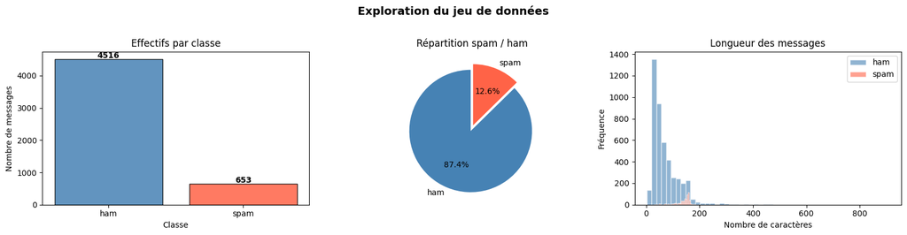

```
Statistiques de longueur par classe :
        count   mean   std   min    25%    50%    75%    max
label
ham    4516.0   70.5  56.4   2.0   34.0   52.0   90.0  910.0
spam    653.0  137.9  30.1  13.0  132.0  149.0  157.0  224.0
```

```python
# Visualisation de la distribution des classes et de la longueur des messages.
# Les messages spam sont généralement plus longs que les messages ham,
# ce qui constitue une première piste discriminante pour les modèles.

df['longueur'] = df['message'].apply(len)

fig, axes = plt.subplots(1, 3, figsize=(16, 4))

# -- Diagramme en barres : effectifs --
counts = df['label'].value_counts()
axes[0].bar(counts.index, counts.values,
            color=['steelblue', 'tomato'], edgecolor='black', alpha=0.85)
axes[0].set_title('Effectifs par classe', fontsize=12)
axes[0].set_xlabel('Classe')
axes[0].set_ylabel('Nombre de messages')
for i, v in enumerate(counts.values):
    axes[0].text(i, v + 30, str(v), ha='center', fontweight='bold')

# -- Diagramme circulaire --
axes[1].pie(
    counts.values,
    labels=counts.index,
    autopct='%1.1f%%',
    colors=['steelblue', 'tomato'],
    startangle=90,
    explode=(0.05, 0.05)
)
axes[1].set_title('Répartition spam / ham', fontsize=12)

# -- Distribution des longueurs par classe --
for label, color in zip(['ham', 'spam'], ['steelblue', 'tomato']):
    axes[2].hist(
        df[df['label'] == label]['longueur'],
        bins=50, alpha=0.6, label=label, color=color, edgecolor='white'
    )
axes[2].set_title('Longueur des messages', fontsize=12)
axes[2].set_xlabel('Nombre de caractères')
axes[2].set_ylabel('Fréquence')
axes[2].legend()

plt.suptitle('Exploration du jeu de données', fontsize=14, fontweight='bold', y=1.02)
plt.tight_layout()
plt.show()

print('Statistiques de longueur par classe :')
print(df.groupby('label')['longueur'].describe().round(1))
```

## 4. Prétraitement des données

```python
# Encodage de la variable cible : 'spam' -> 1, 'ham' -> 0.
# LabelEncoder assigne les valeurs par ordre alphabétique : ham = 0, spam = 1.

le = LabelEncoder()
df['label_enc'] = le.fit_transform(df['label'])

print('Correspondance des labels :')
for cls, enc in zip(le.classes_, le.transform(le.classes_)):
    print(f"  '{cls}' -> {enc}")
```

```
Correspondance des labels :
  'ham' -> 0
  'spam' -> 1
```

```python
# Nettoyage textuel pour le Modèle 1 (Embedding + BiLSTM).
# On conserve les chiffres car ils sont fréquents dans les spams (numéros courts, montants).
# Note : les textes originaux seront utilisés pour DistilBERT qui gère sa propre tokenisation.

def nettoyer_texte(texte):
    """
    Nettoie un SMS pour la tokenisation Keras :
    - Mise en minuscules
    - Suppression des caractères spéciaux non alphanumériques
    - Normalisation des espaces multiples
    """
    texte = texte.lower()
    texte = re.sub(r'[^a-z0-9\s]', '', texte)
    texte = re.sub(r'\s+', ' ', texte).strip()
    return texte

df['message_clean'] = df['message'].apply(nettoyer_texte)

# Vérification sur des exemples de spam
print('Exemples avant / après nettoyage (spam) :')
for i in df[df['label'] == 'spam'].index[:3]:
    print(f"  Original : {df['message'].iloc[i][:80]}")
    print(f"  Nettoyé  : {df['message_clean'].iloc[i][:80]}")
    print()
```

```
Exemples avant / après nettoyage (spam) :
  Original : Free entry in 2 a wkly comp to win FA Cup final tkts 21st May 2005. Text FA to 8
  Nettoyé  : free entry in 2 a wkly comp to win fa cup final tkts 21st may 2005 text fa to 87

  Original : FreeMsg Hey there darling it's been 3 week's now and no word back! I'd like some
  Nettoyé  : freemsg hey there darling its been 3 weeks now and no word back id like some fun

  Original : WINNER!! As a valued network customer you have been selected to receivea å£900 p
  Nettoyé  : winner as a valued network customer you have been selected to receivea 900 prize
```

```python
# Séparation train / test avec stratification (ratio 80 / 20).
# La stratification garantit que les proportions spam/ham sont identiques
# dans les deux sous-ensembles, ce qui est essentiel avec un jeu déséquilibré.
# On effectue deux splits parallèles :
#   - messages nettoyés pour le Modèle 1
#   - messages originaux pour DistilBERT (Modèle 2)

X_clean = df['message_clean'].values
X_orig  = df['message'].values
y       = df['label_enc'].values

X_train, X_test, y_train, y_test = train_test_split(
    X_clean, y, test_size=0.2, random_state=SEED, stratify=y
)
X_train_orig, X_test_orig, _, _ = train_test_split(
    X_orig, y, test_size=0.2, random_state=SEED, stratify=y
)

print(f"Taille du jeu d'entraînement : {len(X_train)} exemples")
print(f"Taille du jeu de test        : {len(X_test)} exemples")
print(f"Proportion de spam (train)   : {y_train.mean():.2%}")
print(f"Proportion de spam (test)    : {y_test.mean():.2%}")
```

```
Taille du jeu d'entraînement : 4135 exemples
Taille du jeu de test        : 1034 exemples
Proportion de spam (train)   : 12.62%
Proportion de spam (test)    : 12.67%
```

## 5. Modèle 1 - Réseau de neurones simple avec Embedding + BiLSTM

Conformément aux recommandations de l'énoncé, nous commençons par **un modèle simple**. La couche d'Embedding apprend des représentations vectorielles des mots directement sur nos données. Le BiLSTM capture les dépendances séquentielles dans les deux sens de lecture.

```python
# Paramètres de tokenisation.
# VOCAB_SIZE    : 10 000 mots les plus fréquents du corpus (couvre la quasi-totalité des SMS).
# MAX_LEN       : 100 tokens - les SMS dépassent rarement 160 caractères.
# EMBEDDING_DIM : dimension des vecteurs de représentation des mots.

VOCAB_SIZE    = 10000
MAX_LEN       = 100
EMBEDDING_DIM = 64

# Le tokeniseur est ajusté uniquement sur les données d'entraînement
# pour éviter toute fuite d'information depuis le jeu de test.
tokenizer = Tokenizer(num_words=VOCAB_SIZE, oov_token='<OOV>')
tokenizer.fit_on_texts(X_train)

print(f"Taille du vocabulaire détecté : {len(tokenizer.word_index)} mots")
print(f"Vocabulaire limité à          : {VOCAB_SIZE} mots")
```

```
Taille du vocabulaire détecté : 8201 mots
Vocabulaire limité à          : 10000 mots
```

```python
# Conversion des textes en séquences d'entiers puis padding.
# Chaque mot est remplacé par son indice dans le vocabulaire.
# padding='post'    : les zéros sont ajoutés en fin de séquence (plus courant pour les LSTM).
# truncating='post' : les séquences trop longues sont tronquées par la fin.

X_train_seq = tokenizer.texts_to_sequences(X_train)
X_test_seq  = tokenizer.texts_to_sequences(X_test)

X_train_pad = pad_sequences(X_train_seq, maxlen=MAX_LEN, padding='post', truncating='post')
X_test_pad  = pad_sequences(X_test_seq,  maxlen=MAX_LEN, padding='post', truncating='post')

print(f"Forme des données d'entraînement après padding : {X_train_pad.shape}")
print(f"Forme des données de test après padding        : {X_test_pad.shape}")
```

```
Forme des données d'entraînement après padding : (4135, 100)
Forme des données de test après padding        : (1034, 100)
```

```python
# Architecture du Modèle 1 : Embedding -> BiLSTM -> Dense -> Sortie sigmoïde.
# Le BiLSTM (bidirectionnel) lit la séquence dans les deux sens,
# ce qui permet de capturer des indices contextuels avant et après chaque mot.
# Le Dropout réduit le surapprentissage en désactivant aléatoirement des neurones.

def construire_modele_simple(vocab_size, embedding_dim, max_len):
    modele = keras.Sequential([
        # Couche d'embedding : transforme les indices en vecteurs denses
        layers.Embedding(
            input_dim=vocab_size,
            output_dim=embedding_dim,
            input_length=max_len,
            name='embedding'
        ),
        # BiLSTM : capture les relations séquentielles dans les deux directions
        layers.Bidirectional(
            layers.LSTM(64, dropout=0.2, recurrent_dropout=0.2),
            name='bilstm'
        ),
        # Couche dense intermédiaire avec activation ReLU
        layers.Dense(32, activation='relu', name='dense_1'),
        layers.Dropout(0.3, name='dropout'),
        # Couche de sortie : probabilité d'être un spam (valeur entre 0 et 1)
        layers.Dense(1, activation='sigmoid', name='sortie')
    ])
    return modele

modele1 = construire_modele_simple(VOCAB_SIZE, EMBEDDING_DIM, MAX_LEN)

# Compilation : optimiseur Adam, entropie croisée binaire pour la classification binaire
modele1.compile(
    optimizer='adam',
    loss='binary_crossentropy',
    metrics=['accuracy']
)

modele1.summary()
```

```
WARNING:tensorflow:From c:\Users\aicha\anaconda3\envs\nlp_env\lib\site-packages\tf_keras\src\layers\rnn\lstm.py:149: The name tf.executing_eagerly_outside_functions is deprecated. Please use tf.compat.v1.executing_eagerly_outside_functions instead.

WARNING:tensorflow:From c:\Users\aicha\anaconda3\envs\nlp_env\lib\site-packages\tf_keras\src\optimizers\__init__.py:317: The name tf.train.Optimizer is deprecated. Please use tf.compat.v1.train.Optimizer instead.

Model: "sequential"
_________________________________________________________________
 Layer (type)                Output Shape              Param #
=================================================================
 embedding (Embedding)       (None, 100, 64)           640000

 bilstm (Bidirectional)      (None, 128)               66048

 dense_1 (Dense)             (None, 32)                4128

 dropout (Dropout)           (None, 32)                0

 sortie (Dense)              (None, 1)                 33

=================================================================
Total params: 710209 (2.71 MB)
Trainable params: 710209 (2.71 MB)
Non-trainable params: 0 (0.00 Byte)
_________________________________________________________________
```

```python
# Définition des callbacks pour optimiser l'entraînement.
# EarlyStopping      : arrête si la perte de validation ne progresse plus (patience=3 époques)
#                      et restaure automatiquement les meilleurs poids.
# ReduceLROnPlateau  : réduit le taux d'apprentissage de moitié en cas de stagnation,
#                      ce qui aide le modèle à converger vers un meilleur minimum local.

callbacks_m1 = [
    EarlyStopping(
        monitor='val_loss',
        patience=3,
        restore_best_weights=True,
        verbose=1
    ),
    ReduceLROnPlateau(
        monitor='val_loss',
        factor=0.5,
        patience=2,
        verbose=1
    )
]

print('Entraînement du Modèle 1 (Embedding + BiLSTM)...')
historique1 = modele1.fit(
    X_train_pad, y_train,
    epochs=15,
    batch_size=32,
    validation_split=0.15,
    callbacks=callbacks_m1,
    verbose=1
)
```

```
Entraînement du Modèle 1 (Embedding + BiLSTM)...
WARNING:tensorflow:From c:\Users\aicha\anaconda3\envs\nlp_env\lib\site-packages\tf_keras\src\utils\tf_utils.py:492: The name tf.ragged.RaggedTensorValue is deprecated. Please use tf.compat.v1.ragged.RaggedTensorValue instead.

WARNING:tensorflow:From c:\Users\aicha\anaconda3\envs\nlp_env\lib\site-packages\tf_keras\src\engine\base_layer_utils.py:384: The name tf.executing_eagerly_outside_functions is deprecated. Please use tf.compat.v1.executing_eagerly_outside_functions instead.

Epoch 4: ReduceLROnPlateau reducing learning rate to 0.0005000000237487257.
Epoch 5: early stopping
Restoring model weights from the end of the best epoch: 2.
```

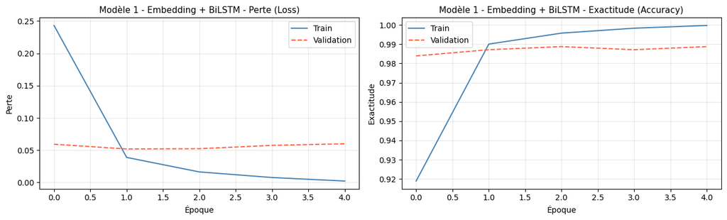

```python
# Visualisation des courbes d'apprentissage du Modèle 1.
# Une courbe de validation qui suit la courbe d'entraînement indique une bonne généralisation.
# Un écart croissant entre les deux signalerait du surapprentissage (overfitting).

def tracer_historique(historique, titre):
    fig, axes = plt.subplots(1, 2, figsize=(13, 4))

    axes[0].plot(historique.history['loss'], label='Train', color='steelblue')
    axes[0].plot(historique.history['val_loss'], label='Validation',
                 color='tomato', linestyle='--')
    axes[0].set_title(f'{titre} - Perte (Loss)', fontsize=11)
    axes[0].set_xlabel('Époque')
    axes[0].set_ylabel('Perte')
    axes[0].legend()
    axes[0].grid(alpha=0.3)

    axes[1].plot(historique.history['accuracy'], label='Train', color='steelblue')
    axes[1].plot(historique.history['val_accuracy'], label='Validation',
                 color='tomato', linestyle='--')
    axes[1].set_title(f'{titre} - Exactitude (Accuracy)', fontsize=11)
    axes[1].set_xlabel('Époque')
    axes[1].set_ylabel('Exactitude')
    axes[1].legend()
    axes[1].grid(alpha=0.3)

    plt.tight_layout()
    plt.show()

tracer_historique(historique1, 'Modèle 1 - Embedding + BiLSTM')
```

```python
# Évaluation du Modèle 1 sur le jeu de test.
# Trois métriques complémentaires sont calculées :
#   - Accuracy  : taux global de classification correcte
#   - F1-Score  : moyenne harmonique précision/rappel, adaptée aux classes déséquilibrées
#   - AUC-ROC   : capacité discriminante, indépendante du seuil de décision

y_pred_proba1 = modele1.predict(X_test_pad).flatten()
y_pred1       = (y_pred_proba1 >= 0.5).astype(int)

acc1 = accuracy_score(y_test, y_pred1)
f1_1 = f1_score(y_test, y_pred1)
roc1 = roc_auc_score(y_test, y_pred_proba1)

print('=' * 52)
print('Résultats - Modèle 1 (Embedding + BiLSTM)')
print('=' * 52)
print(f'  Exactitude (Accuracy) : {acc1:.4f}')
print(f'  Score F1 (spam)       : {f1_1:.4f}')
print(f'  AUC-ROC               : {roc1:.4f}')
print()
print('Rapport de classification détaillé :')
print(classification_report(y_test, y_pred1, target_names=['ham', 'spam']))
```

```
====================================================
Résultats - Modèle 1 (Embedding + BiLSTM)
====================================================
  Exactitude (Accuracy) : 0.9836
  Score F1 (spam)       : 0.9333
  AUC-ROC               : 0.9840

Rapport de classification détaillé :
              precision    recall  f1-score   support

         ham       0.99      0.99      0.99       903
        spam       0.96      0.91      0.93       131

    accuracy                           0.98      1034
   macro avg       0.97      0.95      0.96      1034
weighted avg       0.98      0.98      0.98      1034
```

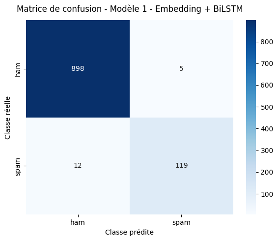

```python
# Matrice de confusion du Modèle 1.
# Lecture :
#   - Vrais négatifs (haut gauche)  : ham correctement identifiés
#   - Faux positifs (haut droite)   : ham classifiés comme spam (désagrément utilisateur)
#   - Faux négatifs (bas gauche)    : spam non détectés (risque principal)
#   - Vrais positifs (bas droite)   : spam correctement bloqués

def afficher_matrice_confusion(y_true, y_pred, titre):
    cm = confusion_matrix(y_true, y_pred)
    fig, ax = plt.subplots(figsize=(6, 5))
    sns.heatmap(
        cm, annot=True, fmt='d', cmap='Blues',
        xticklabels=['ham', 'spam'],
        yticklabels=['ham', 'spam'],
        ax=ax
    )
    ax.set_title(f'Matrice de confusion - {titre}', fontsize=12, pad=12)
    ax.set_xlabel('Classe prédite')
    ax.set_ylabel('Classe réelle')
    plt.tight_layout()
    plt.show()

afficher_matrice_confusion(y_test, y_pred1, 'Modèle 1 - Embedding + BiLSTM')
```